# Alunos do 5º ano abaixo do básico no Saeb 2023: modelo logístico

Eixo 4: Educação Básica Municipal (parceria SME Curitiba) · Projetos de Análise de Dados 2026/2

24/11/2026

# 1 Introdução

O relatório descritivo mostrou que 18 grupos de alunos do 5º ano concentram mais alunos abaixo do nível básico do que os demais. Aquela análise olhava uma característica por vez, e muitas delas andam juntas: quem tem nível socioeconômico baixo mora com mais frequência em rua sem asfalto, quem reprovou tende a ser mais velho. Não era possível dizer o que cada característica acrescenta quando as outras já são conhecidas.

Este relatório traz a etapa de modelagem, que responde a essa pergunta com uma regressão logística para cada disciplina. O professor ajustou os dois modelos com as variáveis dicotômicas da seção 4 do relatório descritivo, manteve as significativas e nos enviou as planilhas de coeficientes, com dois pedidos:

1. interpretar cada variável pela razão de chances;
2. verificar na base de teste, agrupando os alunos pela característica e calculando proporções condicionais, se os dados vão na mesma direção do modelo.

Reproduzimos o procedimento do professor com a nossa base de treino e fizemos as duas tarefas com o modelo estimado por nós. A forma de usar a base de teste foi discutida com o professor em reunião: comparar, em probabilidades condicionais, o que o modelo prevê com o que se vê nos alunos que ele não usou. Ao final, mostramos uma aplicação do modelo: dadas as características de um aluno, estimar a probabilidade de ele estar abaixo do básico e se ele está entre os de maior risco.

# 2 Dados e metodologia

## 2.1 Bases

As bases são as mesmas do relatório descritivo: amostra do Saeb 2023 com 10.068 alunos do 5º ano, dividida em treino (9.062 alunos) e teste (1.006 alunos), com sorteio estratificado pelas duas variáveis resposta. O modelo foi estimado só com o treino. A base de teste não participou de nenhuma escolha e foi usada apenas na verificação.

As variáveis resposta são `abaixo_LP` (proficiência em Língua Portuguesa até 150) e `abaixo_MT` (proficiência em Matemática até 175). No treino, 7,7% dos alunos estão abaixo do básico em LP e 11,0% em MT.

## 2.2 Variáveis explicativas

As variáveis explicativas são os 18 grupos da seção 4 do relatório descritivo. Cada uma vale 1 se o aluno pertence ao grupo e 0 caso contrário.

| Bloco | Grupo | Alunos no treino | % do treino |
| --- | --- | --- | --- |
| Trajetória escolar | Já reprovou ao menos uma vez | 921 | 10,2 |
|  | Tem 12 anos ou mais | 668 | 7,4 |
|  | Já abandonou a escola | 553 | 6,1 |
|  | Entrou na escola com 8 anos ou mais | 447 | 4,9 |
| Nível socioeconômico | INSE nos níveis I e II | 1.076 | 11,9 |
|  | Mãe estudou até o 5º ano | 905 | 10,0 |
|  | Não mora com a mãe | 909 | 10,0 |
|  | Sem Wi-Fi em casa | 759 | 8,4 |
| Entorno | Rua sem asfalto ou calçamento | 2.056 | 22,7 |
|  | Rua sem iluminação | 489 | 5,4 |
|  | Escola rural | 1.055 | 11,6 |
| Rotina | Trabalha fora de casa | 1.309 | 14,4 |
|  | Não tem tempo de lazer | 282 | 3,1 |
|  | Não estuda fora da escola | 765 | 8,4 |
| Relação com a escola | Discorda que os professores acreditam nele | 334 | 3,7 |
| Inclusão | Declara deficiência | 249 | 2,7 |
|  | Declara transtorno do espectro autista | 213 | 2,4 |
| Família | Pouco incentivo para ir às aulas | 960 | 10,6 |

## 2.3 Regressão logística

Para cada disciplina, o modelo escreve o logaritmo da chance de o aluno estar abaixo do básico como uma soma:

$$\log\left(\frac{p}{1-p}\right) = \beta_0
+ \beta_1 x_1 + \dots + \beta_k x_k$$

em que $p$ é a probabilidade de estar abaixo do básico e cada $x_j$ é uma das variáveis 0/1. A chance é a razão $p/(1-p)$: uma probabilidade de 20% corresponde a uma chance de 0,25, ou 1 para 4.

O procedimento, igual ao do professor, teve três passos:

1. ajustar o modelo com as 18 variáveis na base de treino;
2. manter as variáveis com p < 0,05 (teste de Wald);
3. reestimar o modelo só com as variáveis mantidas.

O objetivo desta etapa é entender o processo. A seleção pelo valor-p em uma única rodada é simples e não pretende ser a melhor escolha de variáveis possível.

## 2.4 Razão de chances

A razão de chances de uma variável é $e^{\beta_j}$. Ela diz por quanto a chance de estar abaixo do básico é multiplicada quando o aluno tem a característica, comparado a um aluno igual nas outras variáveis do modelo e que não a tem. Uma razão de 1 indica que a característica não muda a chance, e uma razão de 1,50 indica chance 50% maior. O intervalo de confiança de 95% foi calculado pelo método de Wald, $e^{\beta_j \pm 1{,}96 \, EP}$. Se o intervalo não contém o 1, a variável é significativa a 5%.

# 3 Seleção das variáveis

A tabela mostra o modelo com as 18 variáveis. As linhas marcadas com “sai” são as que não atingiram p < 0,05 e ficaram fora do modelo final daquela disciplina.

| Grupo | Razão de chances LP | Razão de chances MT |
| --- | --- | --- |
| Já reprovou ao menos uma vez | 1,85 (p < 0,001) | 1,99 (p < 0,001) |
| Tem 12 anos ou mais | 1,80 (p < 0,001) | 1,66 (p < 0,001) |
| Já abandonou a escola | 1,32 (p = 0,047) | 1,16 (p = 0,237) · sai |
| Entrou na escola com 8 anos ou mais | 1,77 (p < 0,001) | 1,82 (p < 0,001) |
| INSE nos níveis I e II | 1,70 (p < 0,001) | 2,00 (p < 0,001) |
| Mãe estudou até o 5º ano | 1,02 (p = 0,864) · sai | 1,18 (p = 0,106) · sai |
| Não mora com a mãe | 1,66 (p < 0,001) | 1,54 (p < 0,001) |
| Sem Wi-Fi em casa | 1,68 (p < 0,001) | 1,33 (p = 0,011) |
| Rua sem asfalto ou calçamento | 1,41 (p < 0,001) | 1,53 (p < 0,001) |
| Rua sem iluminação | 0,88 (p = 0,416) · sai | 1,15 (p = 0,307) · sai |
| Escola rural | 1,36 (p = 0,008) | 1,31 (p = 0,007) |
| Trabalha fora de casa | 1,87 (p < 0,001) | 1,34 (p = 0,001) |
| Não tem tempo de lazer | 1,79 (p < 0,001) | 1,66 (p < 0,001) |
| Não estuda fora da escola | 1,54 (p < 0,001) | 1,32 (p = 0,014) |
| Discorda que os professores acreditam nele | 1,90 (p < 0,001) | 1,60 (p = 0,002) |
| Declara deficiência | 1,66 (p = 0,011) | 1,71 (p = 0,002) |
| Declara transtorno do espectro autista | 1,35 (p = 0,185) · sai | 2,06 (p < 0,001) |
| Pouco incentivo para ir às aulas | 1,56 (p < 0,001) | 1,35 (p = 0,004) |

Ficam 15 variáveis em Língua Portuguesa e 15 em Matemática. Duas saem dos dois modelos: mãe que estudou até o 5º ano e rua sem iluminação. Em LP sai também o transtorno do espectro autista, e em MT sai o abandono escolar.

Sair do modelo não quer dizer que o grupo vá bem. No relatório descritivo, os filhos de mães que estudaram até o 5º ano tinham proporção abaixo do básico bem maior que a dos demais. O que o modelo mostra é que, conhecidas as outras 17 características, essa informação acrescenta pouco: a razão de chances cai para 1,02 em LP e 1,18 em MT. A explicação provável é que a escolaridade da mãe acompanha o nível socioeconômico, que já está no modelo pelo INSE. O mesmo vale para a rua sem iluminação, que acompanha a rua sem asfalto.

O abandono fica no limite. Em LP ele entra com p = 0,047, muito perto do corte, e em MT sai com p = 0,237. O transtorno do espectro autista tem razão de chances de 1,35 em LP, com p = 0,185, e é a variável de maior razão de chances em MT. São 213 alunos no treino, e com um grupo desse tamanho o modelo tem pouca precisão.

# 4 Interpretação das razões de chances

## 4.1 Modelo final

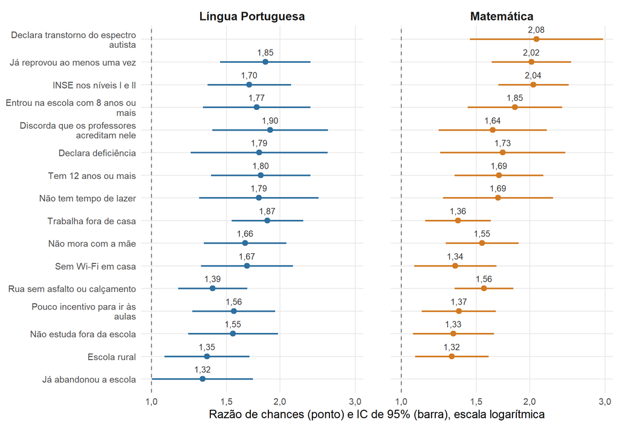

| Bloco | Grupo | Razão de chances LP (IC 95%) | Razão de chances MT (IC 95%) |
| --- | --- | --- | --- |
| Trajetória escolar | Já reprovou ao menos uma vez | 1,85 (1,45 a 2,36) | 2,02 (1,63 a 2,50) |
|  | Tem 12 anos ou mais | 1,80 (1,38 a 2,36) | 1,69 (1,33 a 2,15) |
|  | Já abandonou a escola | 1,32 (1,00 a 1,73) | fora do modelo |
|  | Entrou na escola com 8 anos ou mais | 1,77 (1,32 a 2,36) | 1,85 (1,43 a 2,38) |
| Nível socioeconômico | INSE nos níveis I e II | 1,70 (1,36 a 2,12) | 2,04 (1,69 a 2,47) |
|  | Não mora com a mãe | 1,66 (1,33 a 2,07) | 1,55 (1,27 a 1,89) |
|  | Sem Wi-Fi em casa | 1,67 (1,31 a 2,14) | 1,34 (1,07 a 1,67) |
| Entorno | Rua sem asfalto ou calçamento | 1,39 (1,16 a 1,68) | 1,56 (1,34 a 1,83) |
|  | Escola rural | 1,35 (1,07 a 1,70) | 1,32 (1,08 a 1,60) |
| Rotina | Trabalha fora de casa | 1,87 (1,54 a 2,27) | 1,36 (1,14 a 1,62) |
|  | Não tem tempo de lazer | 1,79 (1,29 a 2,47) | 1,69 (1,25 a 2,27) |
|  | Não estuda fora da escola | 1,55 (1,22 a 1,98) | 1,33 (1,07 a 1,65) |
| Relação com a escola | Discorda que os professores acreditam nele | 1,90 (1,39 a 2,59) | 1,64 (1,23 a 2,19) |
| Inclusão | Declara deficiência | 1,79 (1,24 a 2,58) | 1,73 (1,24 a 2,42) |
|  | Declara transtorno do espectro autista | fora do modelo | 2,08 (1,45 a 2,97) |
| Família | Pouco incentivo para ir às aulas | 1,56 (1,25 a 1,95) | 1,37 (1,12 a 1,67) |

Todas as razões de chances são maiores que 1, ou seja, todas as características do modelo aumentam a chance de o aluno estar abaixo do básico. Elas vão de 1,32 a 2,08. No relatório descritivo, a proporção de cada grupo era de uma vez e meia a três vezes a dos demais. As razões do modelo são menores porque cada uma mede o que a característica acrescenta depois de descontadas as outras.

## 4.2 O aluno sem nenhum fator

O intercepto do modelo dá a chance de um aluno que não tem nenhuma das características. Transformado em probabilidade, esse aluno tem 3,2% de probabilidade de estar abaixo do básico em LP e 5,3% em MT. É o ponto de partida sobre o qual as razões de chances atuam.

## 4.3 Leitura por bloco

**Trajetória escolar.** Ter reprovado multiplica a chance por 1,85 em LP e por 2,02 em MT, ou seja, a chance é 85% maior em LP e cerca do dobro em MT. Ter 12 anos ou mais multiplica a chance por 1,80 em LP e 1,69 em MT, e ter entrado na escola com 8 anos ou mais, por 1,77 e 1,85. As três variáveis ficam no modelo ao mesmo tempo, o que indica que cada uma traz informação além das outras duas, mesmo sendo relacionadas. O abandono só aparece em LP, com a menor razão do modelo (1,32) e intervalo que encosta no 1.

**Nível socioeconômico e família.** Estar nos níveis I e II do INSE multiplica a chance por 1,70 em LP e por 2,04 em MT, onde é uma das maiores razões do modelo. Não morar com a mãe (1,66 em LP e 1,55 em MT) e não ter Wi-Fi em casa (1,67 e 1,34) continuam associados mesmo com o INSE no modelo. O pouco incentivo da família para ir às aulas tem razão de 1,56 em LP e 1,37 em MT.

**Entorno.** Morar em rua sem asfalto ou calçamento multiplica a chance por 1,39 em LP e 1,56 em MT. Estudar em escola rural, por 1,35 e 1,32. São razões menores que as dos outros blocos, mas a rua sem asfalto é o maior grupo do modelo, com 2.056 alunos no treino.

**Rotina.** Trabalhar fora de casa é o caso em que as disciplinas mais se afastam: razão de 1,87 em LP e de 1,36 em MT. Não ter tempo de lazer (1,79 e 1,69) e não estudar fora da escola (1,55 e 1,33) também são mais fortes em LP.

**Relação com a escola.** Discordar que os professores acreditam nele tem a maior razão de chances em LP (1,90) e 1,64 em MT. O grupo é pequeno (334 alunos no treino), e por isso o intervalo é largo.

**Inclusão.** Declarar deficiência multiplica a chance por 1,79 em LP e 1,73 em MT. O transtorno do espectro autista só entra em MT, com a maior razão do modelo (2,08).

## 4.4 Chance não é probabilidade

Uma razão de chances de 1,85 não significa que o aluno que reprovou tem 1,85 vezes a probabilidade de estar abaixo do básico. A razão multiplica a chance, $p/(1-p)$, e as duas contas só dão resultados parecidos quando a probabilidade é pequena. A tabela mostra a probabilidade prevista pelo modelo para alguns perfis, mantendo em zero as demais características.

| Perfil | Probabilidade prevista LP | Probabilidade prevista MT |
| --- | --- | --- |
| Nenhum fator | 3,2% | 5,3% |
| Só reprovou | 5,8% | 10,2% |
| Reprovou e tem 12 anos ou mais | 10,0% | 16,1% |
| Reprovou, tem 12 anos ou mais e INSE I ou II | 15,8% | 28,1% |
| Os três anteriores e rua sem asfalto | 20,8% | 37,9% |

Em LP, o aluno que só reprovou passa de 3,2% para 5,8%. A chance foi multiplicada por 1,85 e a probabilidade, por 1,80, valores ainda próximos. Quando os fatores se acumulam, as razões se multiplicam: reprovar e ter 12 anos ou mais multiplica a chance por 1,85 × 1,80 = 3,34. No perfil com quatro fatores, a probabilidade prevista em MT chega a 37,9%, cerca de 7 vezes a do aluno sem nenhum fator, enquanto a chance é 11 vezes maior.

O modelo supõe que as razões se multiplicam sem interação entre as variáveis. É uma simplificação, conferida na base de teste na seção seguinte.

# 5 Verificação na base de teste

O modelo foi estimado com a base de treino. Para saber se o que ele diz vale para alunos que ele não viu, aplicamos o mesmo modelo, sem reestimar nada, aos 1.006 alunos da base de teste. Cada aluno recebe a probabilidade prevista a partir das suas características. Depois comparamos dois números em cada grupo de alunos:

- **previsto**: a média das probabilidades que o modelo dá aos alunos do grupo;
- **observado**: a proporção desses alunos que está de fato abaixo do básico, ou seja, a probabilidade condicional P(abaixo do básico | grupo), com intervalo de confiança de 95% (Wilson).

Se o previsto cai dentro do intervalo do observado, a interpretação do modelo se confirma em dados novos.

Sem condicionar a nada, os dois números saem praticamente iguais por construção: no teste, o modelo prevê em média 7,4% em LP e 10,9% em MT, e as proporções observadas são 7,7% e 11,0%. Essa comparação não testa o modelo. O teste está em condicionar: olhar grupos específicos de alunos.

## 5.1 Por característica

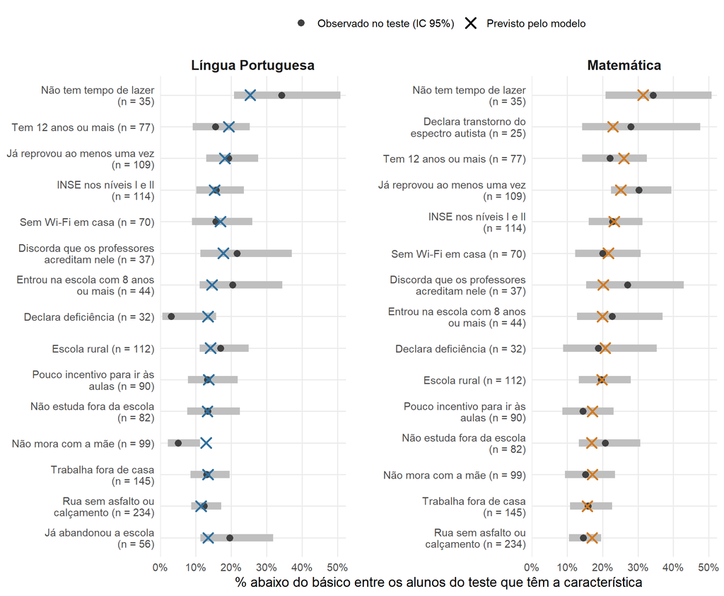

Cada linha é o grupo de alunos do teste que tem a característica. A faixa cinza é o intervalo de confiança da proporção observada, e o X é o que o modelo prevê para esse mesmo grupo.

Em 59 dos 60 grupos (as características de cada modelo, para quem tem e para quem não tem, nas duas disciplinas), o previsto cai dentro do intervalo do observado. Entre os 109 alunos do teste que já reprovaram, por exemplo, o modelo prevê 18,2% em LP e foram observados 19,3%. Para o INSE nos níveis I e II, 15,3% previstos e 15,8% observados em LP, e 23,3% e 22,8% em MT.

A única exceção é não morar com a mãe, em LP. O modelo prevê 12,9%, e no teste só 5 dos 99 alunos estão abaixo do básico (5,1%). Em MT, o mesmo grupo bate com o modelo (17,1% previstos e 15,2% observados). Com 99 alunos, não dá para saber se é acaso da amostra ou se a associação em LP é mais fraca do que o treino indicou.

Os grupos pequenos pedem cuidado, porque o intervalo é tão largo que quase qualquer previsão cabe nele. A deficiência em LP é o caso mais claro: o modelo prevê 13,4%, e no teste só 1 dos 32 alunos está abaixo do básico. O mesmo vale, em menor grau, para o transtorno do espectro autista (25 alunos) e para quem não tem tempo de lazer (35 alunos).

O modelo não erra sistematicamente para um lado: em parte dos grupos o observado fica acima do previsto, em parte fica abaixo.

## 5.2 Acúmulo de fatores

O modelo diz que o risco se acumula: cada característica a mais multiplica a chance. Para conferir, os alunos do teste foram agrupados pelo número de características do modelo que cada um tem.

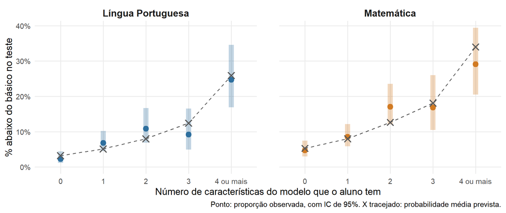

| Fatores | % dos alunos | % dos abaixo do básico LP | Observado LP, % (IC 95%) | Previsto LP, % | % dos abaixo do básico MT | Observado MT, % (IC 95%) | Previsto MT, % |
| --- | --- | --- | --- | --- | --- | --- | --- |
| 0 | 35,2 | 10,4 | 2,3 (1,1 a 4,4) | 3,2 | 15,3 | 4,7 (3,0 a 7,4) | 5,3 |
| 1 | 30,6 | 27,3 | 6,8 (4,5 a 10,2) | 5,1 | 23,4 | 8,5 (5,9 a 12,2) | 8,0 |
| 2 | 15,6 | 22,1 | 10,8 (6,9 a 16,7) | 8,0 | 25,2 | 17,1 (12,1 a 23,6) | 12,6 |
| 3 | 9,7 | 11,7 | 9,2 (4,9 a 16,5) | 12,4 | 13,5 | 16,9 (10,5 a 26,0) | 18,1 |
| 4 ou mais | 8,8 | 28,6 | 24,7 (16,9 a 34,6) | 25,9 | 22,5 | 29,1 (20,5 a 39,4) | 34,0 |

A proporção observada sobe com o número de fatores, de 2,3% entre os alunos sem nenhum para 24,7% entre os que têm quatro ou mais em LP, e de 4,7% para 29,1% em MT. Nas dez faixas, o previsto fica dentro do intervalo do observado. A subida não é perfeita: de dois para três fatores a proporção observada não cresce, nas duas disciplinas. A faixa de três fatores tem menos de 100 alunos, e a diferença cabe no intervalo.

A tabela mostra também onde estão os alunos abaixo do básico. Os 35,2% de alunos sem nenhum fator concentram só 10,4% dos abaixo do básico em LP e 15,3% em MT. Os 8,8% com quatro ou mais concentram 28,6% em LP e 22,5% em MT.

Contar fatores é uma simplificação, porque trata todas as características como se pesassem igual. O modelo não faz isso: ele combina as características pelas suas razões de chances. A verificação seguinte usa a probabilidade que o modelo dá a cada aluno.

## 5.3 Classificação em risco

Uma aplicação do modelo é marcar alunos “em risco”, para que a escola acompanhe esses alunos primeiro. Para isso é preciso um corte na probabilidade prevista. O corte foi definido na base de treino, nunca no teste: “em risco” é estar entre os 20% (ou os 10%) de alunos com maior probabilidade prevista no treino. Os cortes são 9,6% (20% maiores) e 15,1% (10% maiores) em LP, e 13,9% e 20,9% em MT. Depois o mesmo corte foi aplicado aos alunos do teste.

| Disciplina | Em risco | Alunos marcados | Abaixo do básico entre os marcados | Abaixo do básico entre os não marcados | Dos abaixo do básico, quantos foram marcados |
| --- | --- | --- | --- | --- | --- |
| Língua Portuguesa | 20% de maior risco | 205 (20,4%) | 15,6% | 5,6% | 41,6% |
| Língua Portuguesa | 10% de maior risco | 99 (9,8%) | 23,2% | 6,0% | 29,9% |
| Matemática | 20% de maior risco | 209 (20,8%) | 23,9% | 7,7% | 45,0% |
| Matemática | 10% de maior risco | 99 (9,8%) | 26,3% | 9,4% | 23,4% |

Marcando os 20% de maior risco, a escola acompanharia 20,4% dos alunos do teste e alcançaria 41,6% dos que estão abaixo do básico em LP (45,0% em MT). Entre os marcados, 15,6% estão abaixo do básico em LP, quase três vezes os 5,6% dos não marcados. Um corte mais rigoroso, de 10%, marca grupos mais certeiros (23,2% abaixo do básico entre os marcados em LP), mas alcança menos alunos (29,9%).

A marcação funciona como priorização, não como diagnóstico. A maioria dos alunos marcados não está abaixo do básico, e mais da metade dos que estão não é marcada. Isso é coerente com um modelo feito de perguntas de sim ou não de um questionário: muito do desempenho depende de coisas que ele não mede.

## 5.4 Combinações específicas de características

O modelo dá uma probabilidade para qualquer combinação de características, multiplicando as razões de chances, mesmo para combinações que não existem nos dados. A tabela acompanha, no treino, um exemplo em que as características são acrescentadas uma a uma.

| Características (todas ao mesmo tempo) | Alunos no treino | Observado LP | Previsto LP |
| --- | --- | --- | --- |
| Já reprovou ao menos uma vez | 921 | 19,9% | 19,9% |
| + tem 12 anos ou mais | 462 | 23,8% | 23,7% |
| + já abandonou a escola | 87 | 24,1% | 28,7% |
| + entrou na escola com 8 anos ou mais | 15 | 40,0% | 42,3% |
| + INSE nos níveis I e II | 3 | 33,3% | 47,8% |
| + não mora com a mãe | 0 |  |  |

Com uma ou duas características, há centenas de alunos e o previsto coincide com o observado. A partir da terceira, os grupos encolhem rápido: com cinco características são 3 alunos, e com seis, nenhum. Para combinações assim, a probabilidade vem só da suposição de que as razões de chances se multiplicam, sem dado para conferir. Os alunos com muitas características são raros, e nos poucos que existem o modelo tende a superestimar o risco. A probabilidade de uma combinação incomum deve ser lida como indicação de risco alto, não como um valor preciso.

# 6 Aplicação: avaliar um aluno

O modelo pode ser usado para estimar o risco de um aluno a partir das suas características. O script `R/08` traz a função `avalia_aluno()`, e o grupo fez um aplicativo simples em Shiny (`app/app.R`) que faz a mesma conta: marcam-se as características do aluno e o aplicativo mostra a probabilidade prevista em LP e MT e se o aluno está entre os 20% ou os 10% de maior risco.

| Aluno | LP | MT |
| --- | --- | --- |
| Nenhuma característica | 3,2%, fora dos cortes | 5,3%, fora dos cortes |
| Rua sem asfalto | 4,4%, fora dos cortes | 8,0%, fora dos cortes |
| Reprovou e tem 12 anos ou mais | 10,0%, risco moderado | 16,1%, risco moderado |
| Reprovou, 12 anos ou mais, INSE I e II e sem tempo de lazer | 25,2%, risco alto | 39,7%, risco alto |

Uma característica sozinha não coloca o aluno entre os de maior risco. Duas características fortes, como reprovação e idade acima da esperada, já colocam. A seção anterior dá os limites dessa leitura: a marcação acerta o grupo de alunos a priorizar, não o diagnóstico de cada um, e combinações raras de características têm probabilidade menos confiável.

# 7 Conclusões

A regressão logística confirma, com as características consideradas em conjunto, a maior parte do que o relatório descritivo mostrava uma variável por vez. Das 18 características, 15 permanecem associadas a estar abaixo do básico em cada disciplina, todas aumentando a chance, com razões entre 1,32 e 2,08.

A trajetória escolar e o nível socioeconômico têm as razões de chances mais altas e mais estáveis entre as disciplinas: reprovação, idade de 12 anos ou mais, entrada tardia na escola e INSE nos níveis I e II. Em Língua Portuguesa, pesam mais a rotina (trabalhar fora de casa, não ter tempo de lazer) e a percepção de que os professores não acreditam no aluno. Em Matemática, pesam mais o INSE e o transtorno do espectro autista. A escolaridade da mãe e a iluminação da rua deixam de ser significativas quando as outras variáveis estão no modelo.

Para a SME, o resultado útil é o acúmulo. Um aluno sem nenhum dos fatores tem cerca de 3% de probabilidade de estar abaixo do básico em LP e 5% em MT, e cada fator acrescentado multiplica a chance. Boa parte desses fatores, como reprovação, idade e abandono, já está nos registros da escola.

Na base de teste, com alunos que o modelo não viu, o que ele diz se confirma em probabilidades condicionais. Em 59 dos 60 grupos de alunos definidos por uma característica, a probabilidade prevista cai dentro do intervalo da proporção observada, e a proporção observada sobe com o número de características acumuladas, como o modelo prevê. A exceção é não morar com a mãe em LP, e nos grupos pequenos a conclusão fica incerta.

Como ferramenta, o modelo serve para priorizar. Marcando os 20% de alunos de maior risco, a escola alcançaria cerca de 41,6% dos alunos abaixo do básico em LP e 45,0% em MT, mas a maioria dos marcados não estaria abaixo do básico. O aplicativo feito pelo grupo mostra esse uso para um aluno, com o cuidado de que combinações raras de características têm probabilidade menos confiável.

# 8 Limitações

As razões de chances medem associação, não causa. O modelo não permite dizer que acabar com a reprovação ou asfaltar a rua reduziria a proporção de alunos abaixo do básico.

A seleção de variáveis foi feita em uma única rodada pelo valor-p, seguindo o procedimento do professor. Variáveis próximas do corte, como o abandono em LP, poderiam entrar ou sair com outra amostra, e a seleção pelo valor-p tende a deixar os coeficientes das variáveis mantidas um pouco maiores do que seriam.

O modelo não tem interações e trata cada característica como presente ou ausente. Variáveis com gradiente, como o INSE e a idade, perdem informação ao serem cortadas em dois grupos. Sem interações, as razões de chances se multiplicam livremente, e nos poucos alunos com muitas características o modelo tende a superestimar o risco.

A base de teste tem 1.006 alunos, e vários grupos têm menos de 50. Para esses grupos, a verificação é fraca, tanto quando concorda com o modelo quanto quando discorda.

Continuam valendo as limitações do relatório descritivo: a base só inclui alunos que responderam a todo o questionário, o que subestima a proporção abaixo do básico, e as características vêm das respostas de crianças de cerca de 10 anos.

# 9 Próximas etapas

1. Discutir com o professor o uso do modelo para combinações de características que não aparecem nos dados e se vale testar interações.
2. Apresentação final, com a demonstração do aplicativo.